# PSYC2020L Assignment 4

[name]

2025-09-12

## Goals for Review:

- Probability Distributions Review
- *Z*-Scores in R
- Generating Data
- R Packages
- Reading Files

For each question, please make sure you include code output. If the question asks for comparison or further explanation, please make sure to include that as well.

## Setting Up

### 1) Rename this assignment as “Lab 4 Assignment [Last, First].Rmd”

### 2) Check and set (if needed) your working directory. If you’d like to load packages with `library()`, please do so in this block.

```r
here::here()
```

```
## [1] "C:/Users/jessi/OneDrive - Georgia Institute of Technology/Courses/GTA/PSYC 2020/PSYC 2020L Site"
```

### 3) Read in the `tour_de_france.csv` file and assign it to a variable (e.g., `tdf_data`). Display the first six rows of this dataset.

```r
tdf <- rio::import(here::here("slides", "Lab 4 - Probability Distributions", "tour_de_france.csv"))
head(tdf)
```

```
##   year winner_avg_speed total_distance              winner winner_nationality
## 1 1903            25.68           2428       Maurice Garin             France
## 2 1904            25.27           2420        Henri Cornet             France
## 3 1905            27.11           2994   Louis Trousselier             France
## 4 1906            24.46           4545        Rene Pottier             France
## 5 1907            28.47           4488 Lucien Petit-Breton             France
## 6 1908            28.74           4488 Lucien Petit-Breton             France
##   starting_city
## 1         Paris
## 2         Paris
## 3         Paris
## 4         Paris
## 5         Paris
## 6         Paris
```

## Measures of Variability

### 4) What is the variance and SD of `winner_avg_speed`?

```r
var(tdf$winner_avg_speed)
```

```
## [1] 26.94034
```

```r
sd(tdf$winner_avg_speed)
```

```
## [1] 5.190409
```

If they do some square or square root transformation to get one from the other, that works too.

### 5) What is the variance and SD of `total_distance`?

```r
var(tdf$total_distance)
```

```
## [1] 485801.2
```

```r
sd(tdf$total_distance)
```

```
## [1] 696.9944
```

If they do some square or square root transformation to get one from the other, that works too.

## Z-Scores

### 6) Create a new variable within the Tour de France data that contains the `winner_avg_speed` variable standardized. No output needed for this question.

```r
tdf$winner_avg_speed_z <- (tdf$winner_avg_speed - mean(tdf$winner_avg_speed)) / sd(tdf$winner_avg_speed)
```

### 7) Create a new variable within the Tour de France data that contains the `total_distance` variable standardized. No output needed for this question.

```r
tdf$total_distance_z <- (tdf$total_distance - mean(tdf$total_distance)) / sd(tdf$total_distance)
```

### 8) Calculate the variance and SD of the new *z*-scored version `winner_avg_speed`, and compare it to the original, non-*z*-scored version. What differences do you observe?

```r
var(tdf$winner_avg_speed_z)
```

```
## [1] 1
```

```r
sd(tdf$winner_avg_speed_z)
```

```
## [1] 1
```

The variance and SD for the z-scored version are both one. This is because the z-score transformation sets the variance

[or SD]

to one. This obviously much less than the original variance of 26.94 and SD of 5.19.

## Generation from Normal Distribution

### 9) Generate three vectors and assign them to variables: one with 10 draws from a standard normal distribution, one with 50 draws from a standard normal distribution, and one with 100 draws from a standard normal distribution. Display just the vector with 10 draws.

```r
norm10 <- rnorm(10, 0, 1)
norm50 <- rnorm(50, 0, 1)
norm100 <- rnorm(100, 0, 1)
norm10
```

```
##  [1]  0.018773332 -0.759642623 -0.008700049 -0.068767451  0.707531276
##  [6]  0.845746245 -0.401554479 -1.434600751  1.107168300 -1.004408729
```

### 10) Plot a histogram of the vector out of the three that will appear the most representative of the underlying standard normal distribution.

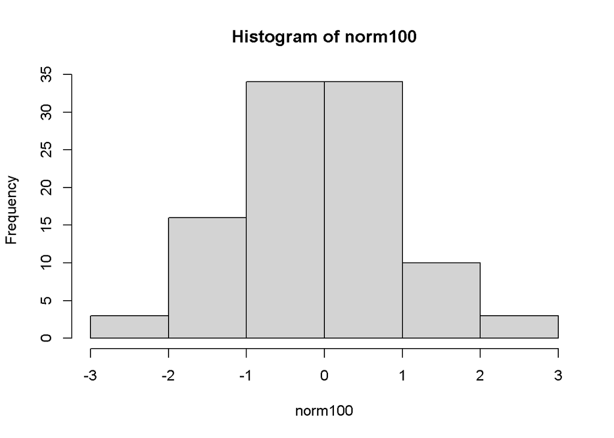

```r
hist(norm100)
```

### 11) Create two more vectors and assign them to variables: one with 1000 draws from a normal distribution with mean of zero and SD of 2 and one with 1000 draws from a normal distribution with mean of 2 and variance of 4. No output is needed for this question.

```r
norm02 <- rnorm(1000, 0, 2)
norm22 <- rnorm(1000, 2, sqrt(4))
```

### 12) Plot each of the two vectors from (11) in a histogram. Set the x-axis limits to be the same for both (hint: use the ? tool if you don’t remember how to set axis limits!), and compare the two plots.

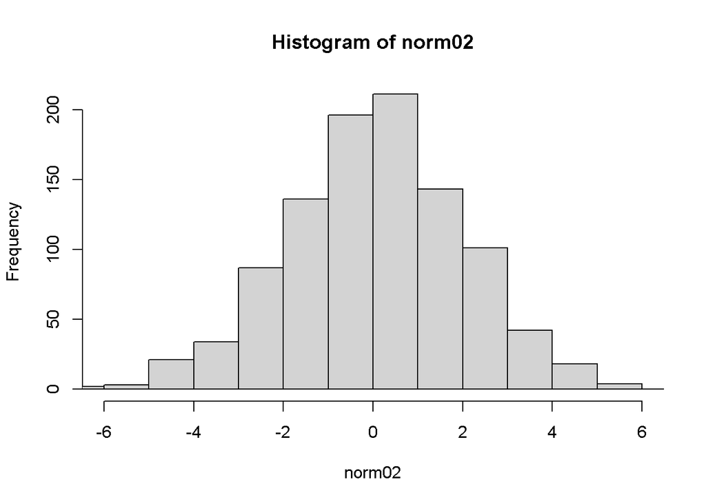

```r
hist(norm02, xlim = c(-6, 6))
```

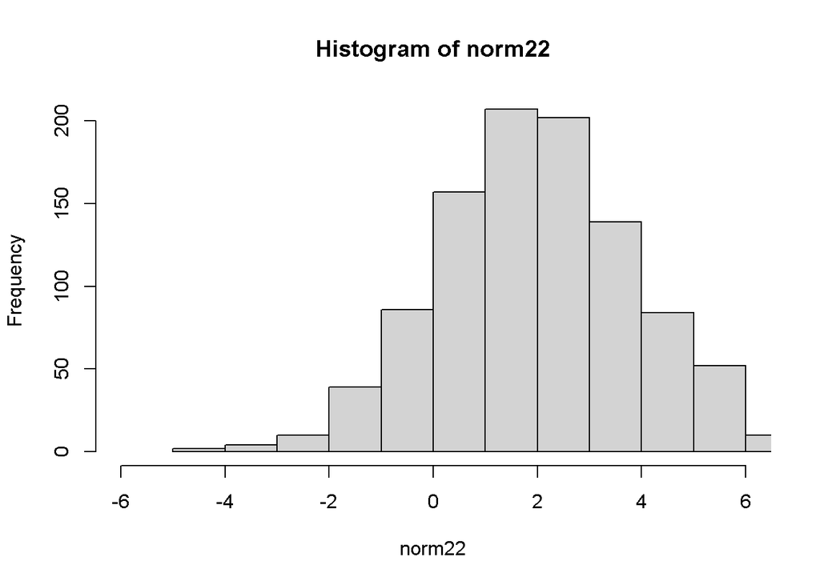

```r
hist(norm22, xlim = c(-6, 6))
```

The histograms have the same variance, but the one with mean of 2 is shifted to the right.

## Matrices

### 13) Create a vector of sequential integers from 1 to 10 and assign it to a variable. No output is needed for this question.

```r
myvec <- 1:10
```

### 14) Turn this vector in a 2 rows x 5 columns matrix that fills in the rows first. Assign this matrix to a variable and display the matrix as output.

```r
mymat <- matrix(myvec, nrow = 2, ncol = 5, byrow = T)
mymat
```

```
##      [,1] [,2] [,3] [,4] [,5]
## [1,]    1    2    3    4    5
## [2,]    6    7    8    9   10
```

## Indexing

### 15) From that matrix, please index:

#### 15a) The second row.

```r
mymat[2, ]
```

```
## [1]  6  7  8  9 10
```

#### 15b) The third column of the first row.

```r
mymat[1, 3]
```

```
## [1] 3
```

#### 15c) The second through fourth columns of the first and second rows.

```r
mymat[1:2, 2:4]
```

```
##      [,1] [,2] [,3]
## [1,]    2    3    4
## [2,]    7    8    9
```